# TRAP

[figure not shown]

# BACKGROUND

# DATA

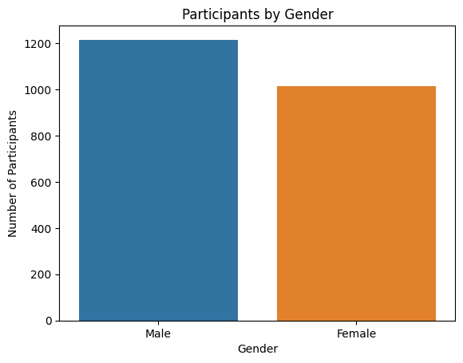

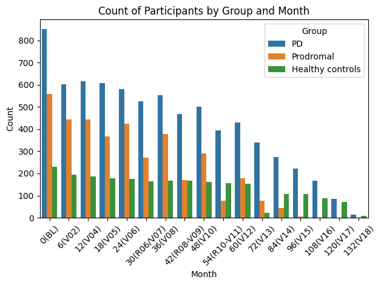

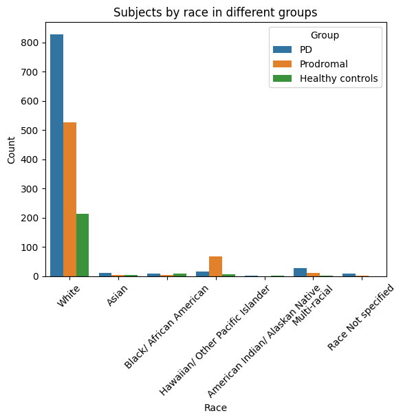

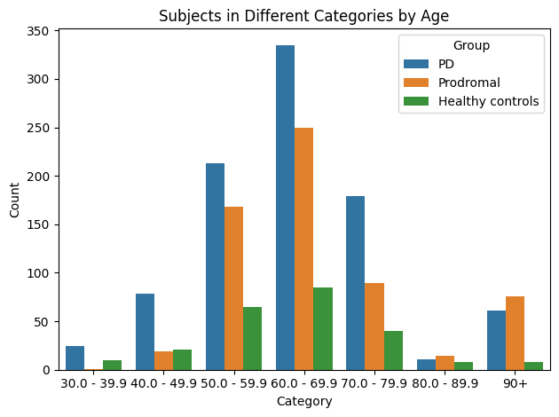

### DATA SUMMARY

```
<class 'pandas.core.frame.DataFrame'>
RangeIndex: 3445 entries, 0 to 3444
Columns: 159 entries, SITE to cogstate
dtypes: float64(131), int64(16), object(12)
memory usage: 4.2+ MB
```

|  | SITE | PATNO | Group | EVENT_ID | YEAR | visit_date | ST_startdate | ST_year1 | ST_year2 | ST_year3 | ST_year4 | ST_year5 | changedx | primdiag | othneuro | age | age_cat | gen | EDUCYRS | educ | HISPLAT | race | fampd_new | fampd_old | duration | ageonset | agediag | DOMSIDE | symptom1 | … |
| --- | --- | --- | --- | --- | --- | --- | --- | --- | --- | --- | --- | --- | --- | --- | --- | --- | --- | --- | --- | --- | --- | --- | --- | --- | --- | --- | --- | --- | --- | --- |
| 0 | 10 | 3000 | 2 | BL | 0 | FEB2011 | NaN | 0 | 0 | 0 | 0 | 0 | NaN | 17.0 | NaN | 69.139726 | 3 | 2 | 18 | 2 | 2 | 1 | 3.0 | 2.0 | NaN | NaN | NaN | NaN | NaN | … |
| 1 | 10 | 3000 | 2 | V04 | 1 | MAR2012 | NaN | 0 | 0 | 0 | 0 | 0 | 0.0 | 17.0 | NaN | 69.139726 | 3 | 2 | 18 | 2 | 2 | 1 | 3.0 | 2.0 | NaN | NaN | NaN | NaN | NaN | … |
| 2 | 10 | 3000 | 2 | V06 | 2 | FEB2013 | NaN | 0 | 0 | 0 | 0 | 0 | 0.0 | 17.0 | NaN | 69.139726 | 3 | 2 | 18 | 2 | 2 | 1 | 3.0 | 2.0 | NaN | NaN | NaN | NaN | NaN | … |
| 3 | 10 | 3000 | 2 | V08 | 3 | MAR2014 | NaN | 0 | 0 | 0 | 0 | 0 | 0.0 | 17.0 | NaN | 69.139726 | 3 | 2 | 18 | 2 | 2 | 1 | 3.0 | 2.0 | NaN | NaN | NaN | NaN | NaN | … |
| 4 | 10 | 3000 | 2 | V10 | 4 | MAR2015 | NaN | 0 | 0 | 0 | 0 | 0 | 0.0 | 17.0 | NaN | 69.139726 | 3 | 2 | 18 | 2 | 2 | 1 | 3.0 | 2.0 | NaN | NaN | NaN | NaN | NaN | … |
| 5 | 10 | 3000 | 2 | V12 | 5 | APR2016 | NaN | 0 | 0 | 0 | 0 | 0 | 0.0 | 17.0 | NaN | 69.139726 | 3 | 2 | 18 | 2 | 2 | 1 | 3.0 | 2.0 | NaN | NaN | NaN | NaN | NaN | … |
| 6 | 10 | 3001 | 1 | BL | 0 | MAR2011 | JUL2012 | 0 | 1 | 1 | 1 | 1 | NaN | 1.0 | NaN | 65.142466 | 2 | 1 | 16 | 2 | 2 | 1 | 3.0 | 2.0 | 10.533333 | 63.591781 | 64.260274 | 2.0 | 1.0 | … |
| 7 | 10 | 3001 | 1 | V04 | 1 | APR2012 | JUL2012 | 0 | 1 | 1 | 1 | 1 | 0.0 | 1.0 | NaN | 65.142466 | 2 | 1 | 16 | 2 | 2 | 1 | 3.0 | 2.0 | 10.533333 | 63.591781 | 64.260274 | 2.0 | 1.0 | … |
| 8 | 10 | 3001 | 1 | V06 | 2 | MAY2013 | JUL2012 | 0 | 1 | 1 | 1 | 1 | 0.0 | 1.0 | NaN | 65.142466 | 2 | 1 | 16 | 2 | 2 | 1 | 3.0 | 2.0 | 10.533333 | 63.591781 | 64.260274 | 2.0 | 1.0 | … |
| 9 | 10 | 3001 | 1 | V08 | 3 | MAY2014 | JUL2012 | 0 | 1 | 1 | 1 | 1 | 0.0 | 1.0 | NaN | 65.142466 | 2 | 1 | 16 | 2 | 2 | 1 | 3.0 | 2.0 | 10.533333 | 63.591781 | 64.260274 | 2.0 | 1.0 | … |
| 10 | 10 | 3001 | 1 | V10 | 4 | APR2015 | JUL2012 | 0 | 1 | 1 | 1 | 1 | 0.0 | 1.0 | NaN | 65.142466 | 2 | 1 | 16 | 2 | 2 | 1 | 3.0 | 2.0 | 10.533333 | 63.591781 | 64.260274 | 2.0 | 1.0 | … |
| 11 | 10 | 3001 | 1 | V12 | 5 | JUN2016 | JUL2012 | 0 | 1 | 1 | 1 | 1 | 0.0 | 1.0 | NaN | 65.142466 | 2 | 1 | 16 | 2 | 2 | 1 | 3.0 | 2.0 | 10.533333 | 63.591781 | 64.260274 | 2.0 | 1.0 | … |
| 12 | 10 | 3002 | 1 | BL | 0 | MAR2011 | AUG2011 | 1 | 1 | 1 | 1 | 1 | NaN | 1.0 | NaN | 67.578082 | 3 | 2 | 16 | 2 | 2 | 1 | 3.0 | 2.0 | 12.900000 | 65.520548 | 66.504110 | 1.0 | 1.0 | … |
| 13 | 10 | 3002 | 1 | V04 | 1 | APR2012 | AUG2011 | 1 | 1 | 1 | 1 | 1 | 0.0 | 1.0 | NaN | 67.578082 | 3 | 2 | 16 | 2 | 2 | 1 | 3.0 | 2.0 | 12.900000 | 65.520548 | 66.504110 | 1.0 | 1.0 | … |
| 14 | 10 | 3002 | 1 | V06 | 2 | APR2013 | AUG2011 | 1 | 1 | 1 | 1 | 1 | 0.0 | 1.0 | NaN | 67.578082 | 3 | 2 | 16 | 2 | 2 | 1 | 3.0 | 2.0 | 12.900000 | 65.520548 | 66.504110 | 1.0 | 1.0 | … |
| 15 | 10 | 3002 | 1 | V08 | 3 | MAR2014 | AUG2011 | 1 | 1 | 1 | 1 | 1 | 0.0 | 1.0 | NaN | 67.578082 | 3 | 2 | 16 | 2 | 2 | 1 | 3.0 | 2.0 | 12.900000 | 65.520548 | 66.504110 | 1.0 | 1.0 | … |
| 16 | 10 | 3002 | 1 | V10 | 4 | MAR2015 | AUG2011 | 1 | 1 | 1 | 1 | 1 | 0.0 | 1.0 | NaN | 67.578082 | 3 | 2 | 16 | 2 | 2 | 1 | 3.0 | 2.0 | 12.900000 | 65.520548 | 66.504110 | 1.0 | 1.0 | … |
| 17 | 10 | 3002 | 1 | V12 | 5 | APR2016 | AUG2011 | 1 | 1 | 1 | 1 | 1 | 0.0 | 1.0 | NaN | 67.578082 | 3 | 2 | 16 | 2 | 2 | 1 | 3.0 | 2.0 | 12.900000 | 65.520548 | 66.504110 | 1.0 | 1.0 | … |
| 18 | 10 | 3003 | 1 | BL | 0 | APR2011 | OCT2012 | 0 | 1 | 1 | 1 | 1 | NaN | 1.0 | NaN | 56.717808 | 2 | 2 | 16 | 2 | 2 | 1 | 3.0 | 2.0 | 24.600000 | 51.827397 | 54.668493 | 2.0 | 0.0 | … |
| 19 | 10 | 3003 | 1 | V04 | 1 | APR2012 | OCT2012 | 0 | 1 | 1 | 1 | 1 | 0.0 | 1.0 | NaN | 56.717808 | 2 | 2 | 16 | 2 | 2 | 1 | 3.0 | 2.0 | 24.600000 | 51.827397 | 54.668493 | 2.0 | 0.0 | … |

TODO: Cleaned the columns with has more than 450 null values, inspected data previously since i will not include the imaging data in the first model and null values comes from the imaging data dropped those columns. Other columns will be dropped is the following list, they are selected based on the dict description. To see what are they about refer to the dictionary and raw data: SITE, EDUCYRS, educ, fampd_old, hy, hy_on (kept nhy, these two are derived data), td_pigd_old, td_pigd_old_on

### Inspect "object" type columns

```
Index(['EVENT_ID', 'APOE', 'SNCA_rs356181', 'SNCA_rs3910105', 'MAPT'], dtype='object')
```

### Subject Group Categories

```
1    2223
2    1038
3     184
Name: Group, dtype: int64
```

### Only one visit per subject

```
1    423
2    196
3     64
Name: Group, dtype: int64
```

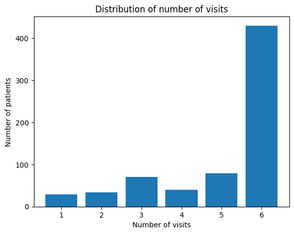

### Check data distribution on each column

#### Multiple visits

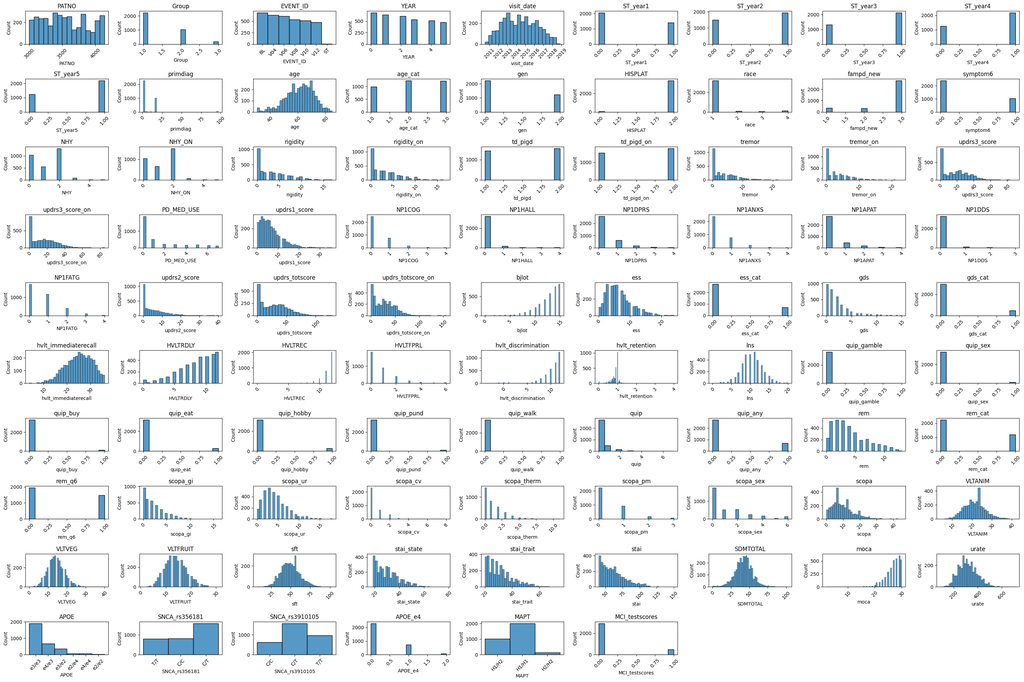

#### Single visit

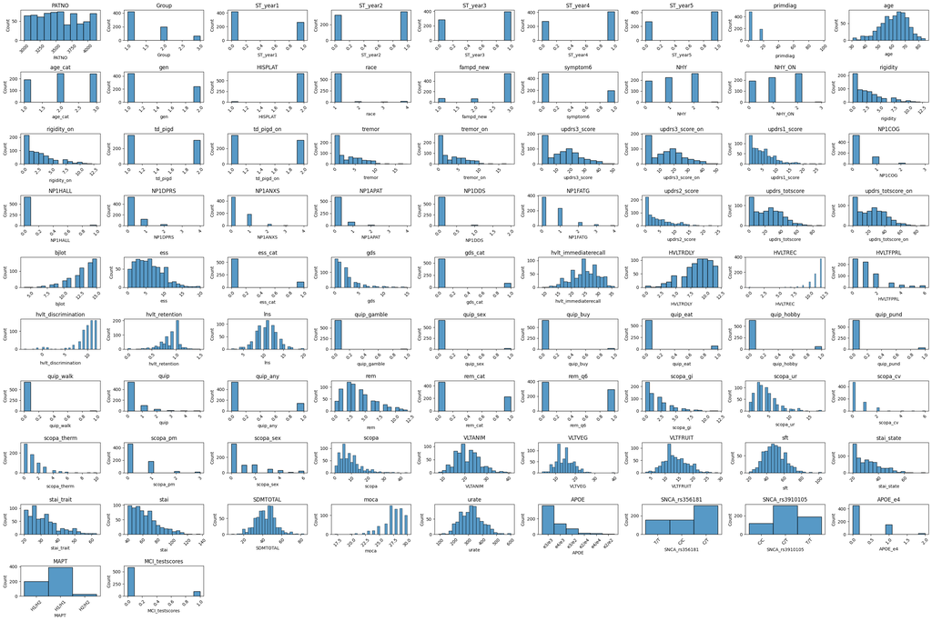

### Inspect for outliers

#### Multiple visits

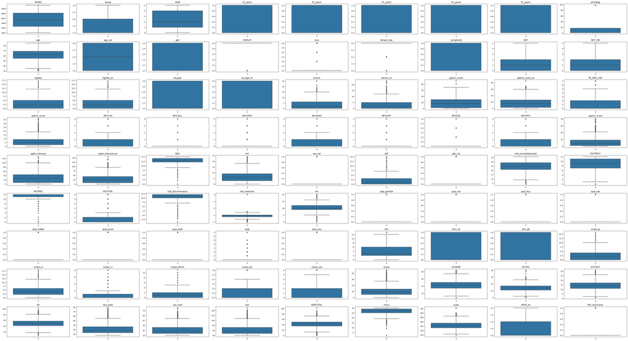

#### Single visit

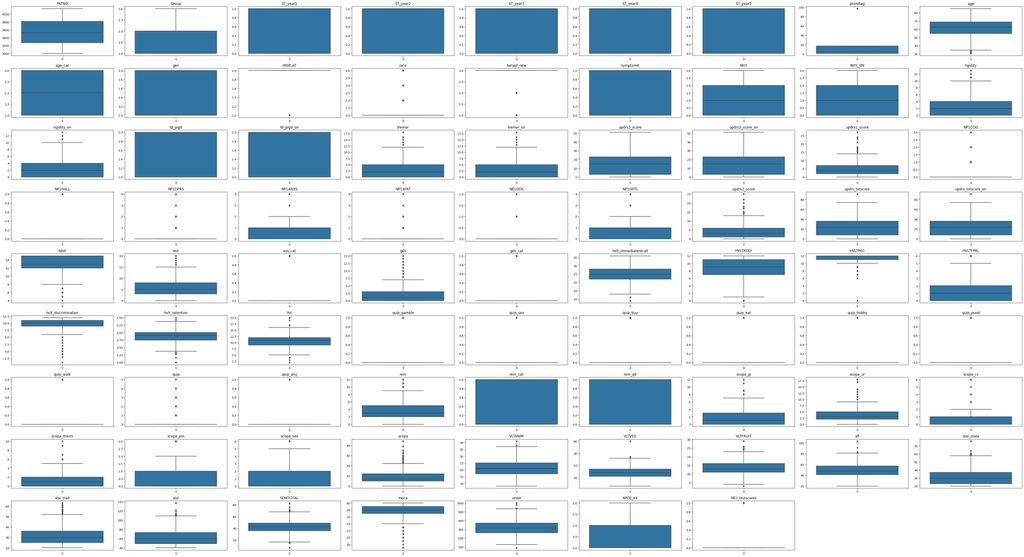

**To keep the subject size balance, within this notebook I will be using only patient and control groups for analysis.**

### Inspect columns' correlation

#### Multiple visits

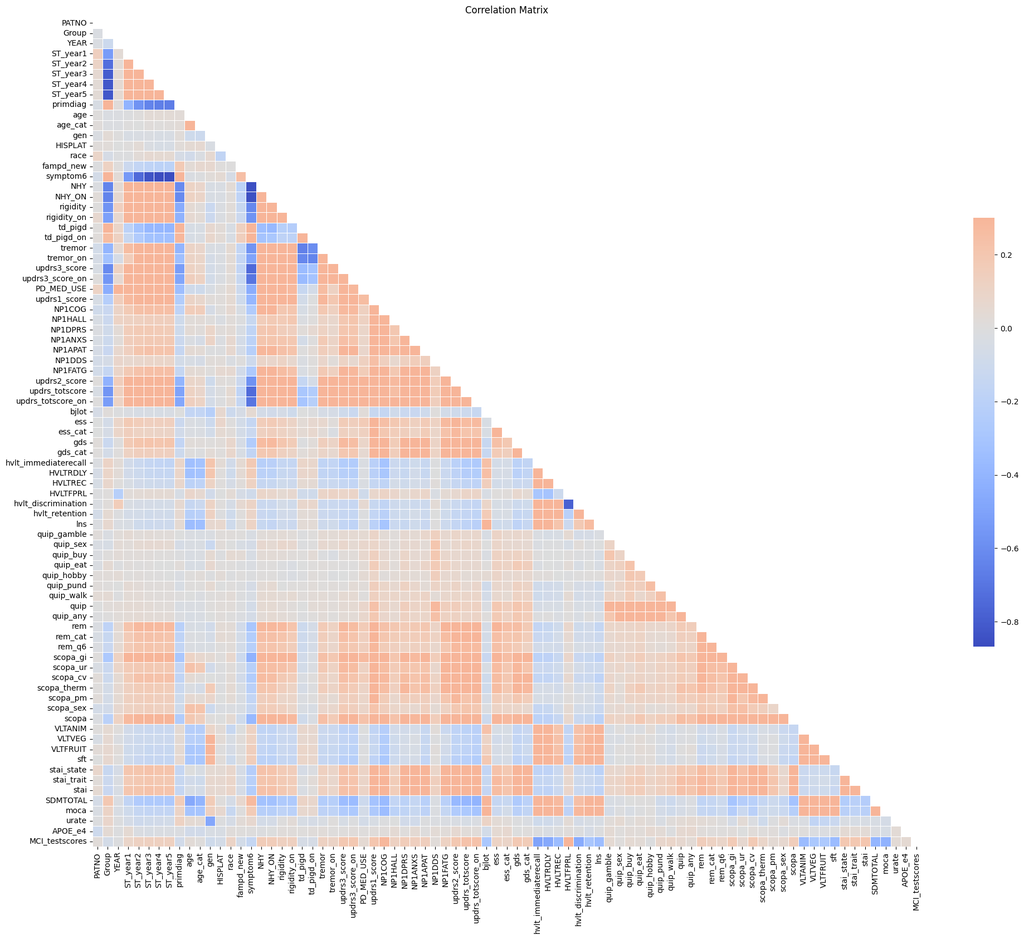

#### Single visit

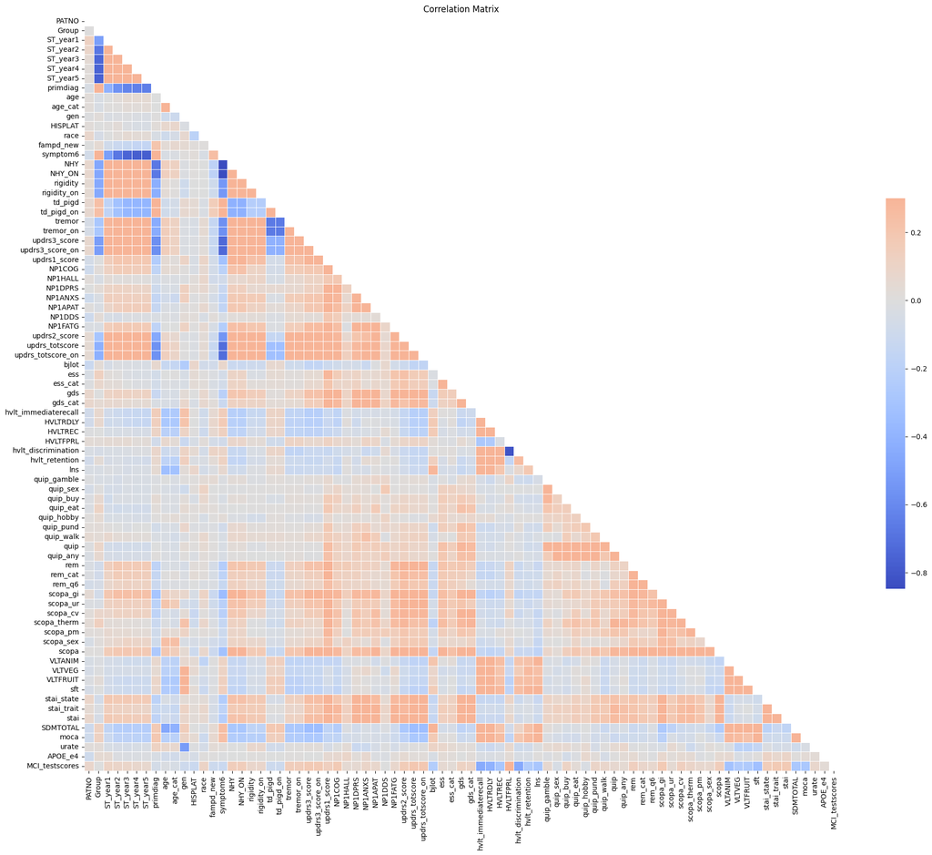

### Distribution of participants

#### Multiple visits

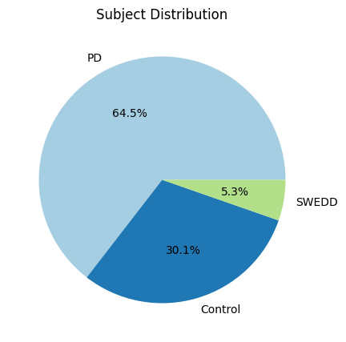

#### Single visit

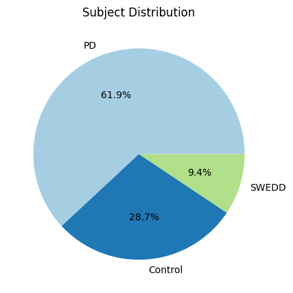

**For the sake of simplicity I will be including only the patient and the control group for the following analysis.**

#### Create two different data frames for further analysis: With and without genetic variants

**Now, time to standardize the data. Two dataframes will be used that is prepared above: all_pc(all patient and controls) and nogen_pc(no genetic data containing patient and control data). In both the columns that has 1 and 2 null values replaced with mean of the column.**

First will analyze without genetic data. Then the genetic data will be hot encoded to mark the variations exist or not exist so that they can be numeric values as well.

#### WITHOUT GENETIC VARIANTS

```
                   Logistic Regression trained.
                  K-Nearest Neighbours trained.
Support Vector Machine (Linear Kernel) trained.
   Support Vector Machine (RBF Kernel) trained.
                        Neural Network trained.
                         Random Forest trained.
                     Gradient Boosting trained.
                              CatBoost trained.
```

#### RESULTS

```
TEST
                   Logistic Regression : 100.000000%
                  K-Nearest Neighbours : 99.462366%
Support Vector Machine (Linear Kernel) : 100.000000%
   Support Vector Machine (RBF Kernel) : 99.462366%
                        Neural Network : 99.462366%
                         Random Forest : 100.000000%
                     Gradient Boosting : 100.000000%
                              CatBoost : 100.000000%
```

#### WITH GENETICS VARIANTS

#### Encode the categorical columns (genetic variants in this context)

### Train the models

```
                   Logistic Regression trained.
                  K-Nearest Neighbours trained.
Support Vector Machine (Linear Kernel) trained.
   Support Vector Machine (RBF Kernel) trained.
                        Neural Network trained.
                         Random Forest trained.
                     Gradient Boosting trained.
                              CatBoost trained.
```

#### RESULTS

```
TEST
                   Logistic Regression : 100.000000%
                  K-Nearest Neighbours : 99.375000%
Support Vector Machine (Linear Kernel) : 100.000000%
   Support Vector Machine (RBF Kernel) : 99.375000%
                        Neural Network : 99.375000%
                         Random Forest : 100.000000%
                     Gradient Boosting : 100.000000%
                              CatBoost : 100.000000%
```

### STUDY SUBJECT PROPERTIES

#### CLEAN THE DIFFERENT INFO CATEGORIES AND MERGE BASED ON THE PATNO

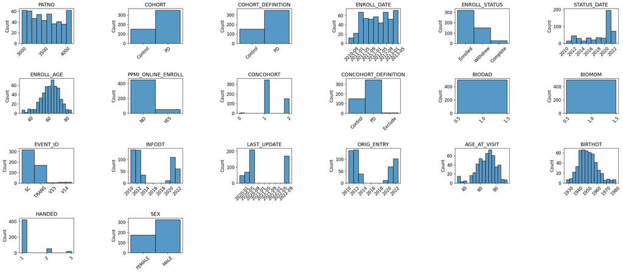

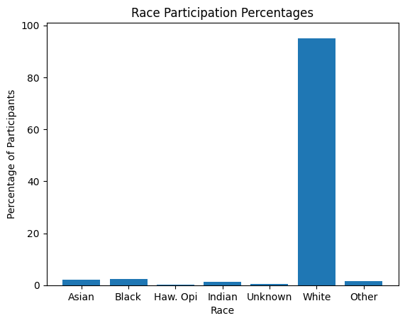